# Soil Moisture - Linear mixed effects model

Model for the effect of mining on soil moisture in Newnes swamps. Code by José R. Ferrer-Paris with contribution from David Keith and Martin Krogh

# Preliminaries

## Load required packages

```r
library(nlme)
library(ggplot2)
```

## Read data from CSV file

Data: Newnes swamps soil moisture survey Jan 2013 - Mar 2022 Martin Krogh & Sarsha Gorissen

Read in the data from csv file, which has a header row for col labels and in which character values are not to be converted to factors.

```r
newnsoil = read.csv("NewnSoilMoist.csv", header=T, row.names=NULL, stringsAsFactors = FALSE)
```

Modify columns in the data frame:

```r
newnsoil$Mine <- factor(newnsoil$Mining,levels=c("Unmined reference", "Mined"))
newnsoil$logYears <- log(newnsoil$Time - 2014)
newnsoil$Rain = newnsoil$Rainfall_3mth
newnsoil$SoilMoisture = newnsoil$Soil_moisture
newnsoil$Site <- factor(newnsoil$Site)
```

# Linear mixed effects model

We are interested in Soil Moisture (in %), and consider three explanatory variables: `log(Years since 2014)`, a factor with two levels for mined and unmined sites (using treatment contrasts), and the rain in the three months prior to sampling.

Check contrasts for the `Mine` factor:

```r
contrasts(newnsoil$Mine)
```

```
                  Mined
Unmined reference     0
Mined                 1
```

We added one random effect of Site and a constant variance function with two different levels for mined and unmined sites. The variance is fixed to one for the control level (`Unmined reference`), and estimate for the treatment level (`Mined`):

```r
mdl000 <- lme(SoilMoisture ~ logYears * Mine + Rain,
              random = ~ 1 | Site,
              weights = varIdent(form= ~ 1 | Mine),
              data=newnsoil)
```

Here is the summary of the fitted model. Degrees of Freedom in the coefficient table are denominator degrees of freedom, see discussion about their interpretation on: https://bbolker.github.io/mixedmodels-misc/glmmFAQ.html#why-doesnt-lme4-display-denominator-degrees-of-freedomp-values-what-other-options-do-i-have

```r
summary(mdl000)
```

```
Linear mixed-effects model fit by REML
  Data: newnsoil
```

|  | AIC | BIC | logLik |
| --- | --- | --- | --- |
|  | 3402.231 | 3434.834 | -1693.116 |

```
Random effects:
 Formula: ~1 | Site
        (Intercept) Residual
StdDev:    9.251101 8.303085

Variance function:
 Structure: Different standard deviations per stratum
 Formula: ~1 | Mine
 Parameter estimates:
Unmined reference             Mined
         1.000000          1.765437
Fixed effects:  SoilMoisture ~ logYears * Mine + Rain
```

|  | Value | Std.Error | DF | t-value | p-value |
| --- | --- | --- | --- | --- | --- |
| (Intercept) | 86.39378 | 5.590549 | 431 | 15.453542 | 0.0000 |
| logYears | -1.77496 | 0.917966 | 431 | -1.933576 | 0.0538 |
| MineMined | -20.43813 | 8.034454 | 4 | -2.543811 | 0.0637 |
| Rain | 0.01962 | 0.003537 | 431 | 5.546988 | 0.0000 |
| logYears:MineMined | -23.87648 | 1.779146 | 431 | -13.420193 | 0.0000 |

```
 Correlation:
                   (Intr) logYrs MinMnd Rain
logYears           -0.214
MineMined          -0.680  0.163
Rain               -0.146 -0.132 -0.004
logYears:MineMined  0.119 -0.508 -0.311  0.009

Standardized Within-Group Residuals:
       Min         Q1        Med         Q3        Max
-6.6708225 -0.5213518  0.1804146  0.5683773  2.4939164

Number of Observations: 440
Number of Groups: 6
```

Approximated 95% confidence intervals for the variance components:

```r
intervals(mdl201,which='var-cov')
```

```
Approximate 95% confidence intervals

 Random Effects:
  Level: Site
                   lower     est.    upper
sd((Intercept)) 4.516312 9.251101 18.94973

 Variance function:
         lower     est.   upper
Mined 1.539334 1.765437 2.02475
attr(,"label")
[1] "Variance function:"

 Within-group standard error:
   lower     est.    upper
7.527907 8.303085 9.158087
```

## Residuals

There is a long tail of negative residuals in reference sites with high predicted values (see lower values in Sites HV and SS in the plot of the prediction).

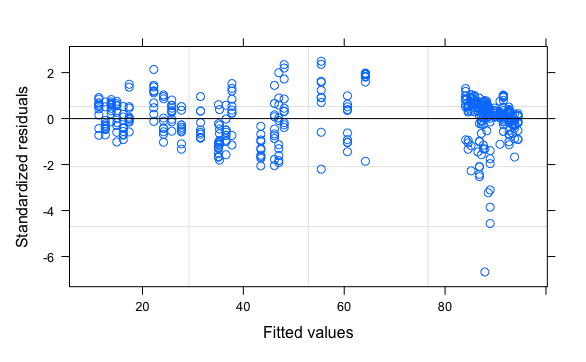

```r
plot(mdl000)
```

We can try transforming our response variable (`arcsin(SoilMoisture/100)`):

```r
newnsoil$tSM <- metafor::transf.arcsin(newnsoil$SoilMoisture/100)
mdl001 <- lme(tSM ~ logYears * Mine + Rain,
              random = ~ 1 | Site,
              weights = varIdent(form= ~ 1 | Mine),
              data=newnsoil)
summary(mdl001)
```

```
Linear mixed-effects model fit by REML
  Data: newnsoil
```

|  | AIC | BIC | logLik |
| --- | --- | --- | --- |
|  | -408.2548 | -375.652 | 212.1274 |

```
Random effects:
 Formula: ~1 | Site
        (Intercept)  Residual
StdDev:   0.1061729 0.1152689

Variance function:
 Structure: Different standard deviations per stratum
 Formula: ~1 | Mine
 Parameter estimates:
Unmined reference             Mined
         1.000000          1.453134
Fixed effects:  tSM ~ logYears * Mine + Rain
```

|  | Value | Std.Error | DF | t-value | p-value |
| --- | --- | --- | --- | --- | --- |
| (Intercept) | 1.2046408 | 0.06534296 | 431 | 18.435663 | 0.0000 |
| logYears | -0.0240017 | 0.01273234 | 431 | -1.885101 | 0.0601 |
| MineMined | -0.2476553 | 0.09285554 | 4 | -2.667103 | 0.0560 |
| Rain | 0.0002998 | 0.00004648 | 431 | 6.450806 | 0.0000 |
| logYears:MineMined | -0.2716860 | 0.02155903 | 431 | -12.601963 | 0.0000 |

```
 Correlation:
                   (Intr) logYrs MinMnd Rain
logYears           -0.257
MineMined          -0.684  0.196
Rain               -0.164 -0.125 -0.005
logYears:MineMined  0.162 -0.583 -0.327  0.010

Standardized Within-Group Residuals:
       Min         Q1        Med         Q3        Max
-5.4132416 -0.5257208  0.1349068  0.5856425  2.6056911

Number of Observations: 440
Number of Groups: 6
```

Compare residuals of this model:

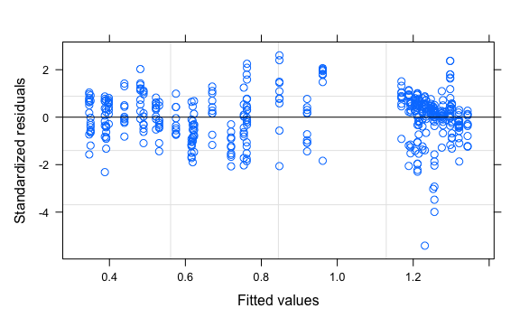

```r
plot(mdl001)
```

Comparing side by side:

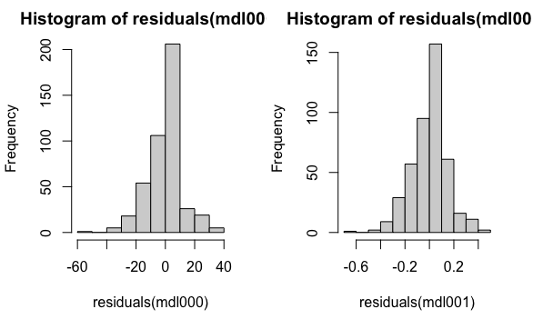

```r
layout(matrix(1:2,ncol=2))
hist(residuals(mdl000))
hist(residuals(mdl001))
```

## Prediction from the model

Approximate 95% confidence intervals of the prediction using “non-parametric case bootstrap coupled with individual residual bootstrap” following instruction in https://stats.stackexchange.com/questions/231074/confidence-intervals-on-predictions-for-a-non-linear-mixed-model-nlme and https://doi.org/10.1002/pst.1561

First we will define a couple of functions:

Get the 95 % confidence intervals of a data.frame/matrix:

```r
get_CI <- function(y,pref="") {
  r1 <- t(apply(y,1,quantile,c(0.025,0.975),na.rm=T))
  setNames(as.data.frame(r1),paste0(pref,c("lwr","upr")))
}
```

Bootstrap sampling based on the fitted model and residuals:

```r
sampfun <- function(fitted,data,idvar="Site") {
  pp <- predict(fitted,level=1)
  rr <- residuals(fitted)
  dd <- data.frame(data,pred=pp,res=rr)
  ## sample groups with replacement
  iv <- levels(data[[idvar]])
  bsamp1 <- sample(iv,size=length(iv),replace=TRUE)
  bsamp2 <- lapply(bsamp1,
                   function(x) {
                     ## within groups, sample *residuals* with replacement
                     ddb <- dd[dd[[idvar]]==x,]
                     ## bootstrapped response = pred + bootstrapped residual
                     ddb$SoilMoisture <- ddb$pred +
                       sample(ddb$res,size=nrow(ddb),replace=TRUE)
                     return(ddb)
                   })
  res <- do.call(rbind,bsamp2)  ## collect results
  if (is(data,"groupedData"))
    res <- groupedData(res,formula=formula(data))
  return(res)
}
```

Return prediction from re-fitted model

```r
pfun <- function(fm) {
  res <- try(predict(fm,newdata=pframe,level=1))
  if (!any(class(res) %in% "try-error"))
    return(res)
}
```

Now we apply this code to get 1000s replicates of predictions at each observation point for three different values of the rain co-variate (ignoring error messages here, and keeping only successful runs):

```r
pframe <- newnsoil
pframe$SoilMoisture <- predict(mdl000,newdata=pframe,level=1)

nresamp <- 1000
yvals <- list()
## we want to consider the full range of rain values
for (qq in c(0.025,0.5,0.975)) {
  pframe$Rain <- quantile(newnsoil$Rain,qq)
  yvals2 <- replicate(nresamp,
                      pfun(update(mdl000,
                                  data=sampfun(mdl000,
                                               newnsoil,
                                               "Site"))))
  yvals <- c(yvals,yvals2[lengths(yvals2)==440])
}
```

Now we apply this code to get the envelope based on the bootstrap:

```r
c2 <- get_CI(as.data.frame(yvals),"boot_")
prd.env <- aggregate(c2,list(Site=newnsoil$Site,Mine=newnsoil$Mine,Time=newnsoil$Time),median)
```

## Figure

Set up the basic elements of the plot:

```r
clrs <- palette()[c(3,7)]
names(clrs) <- c("Unmined reference","Mined")

basic_plot <- ggplot(data = newnsoil) +
  geom_point(aes(x = Time,
                 y = SoilMoisture,
                 colour=Mine),size=2) +
  ggtitle("") +
  xlab("Year") + ylab("Volumetric Soil Moisture (%)") +
  scale_x_continuous(name="Year", breaks=2015:2022) +
  scale_color_discrete(type = clrs)  + theme_bw() + theme(axis.text.x = element_text(angle = 45, vjust = 1, hjust=1)) + guides(colour='none')
```

This is the version of the plot with facets showing the six sites:

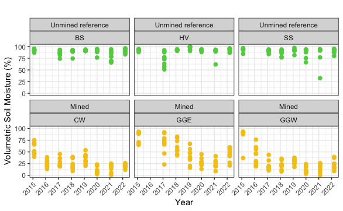

```r
basic_plot + facet_wrap(vars(Mine,Site),ncol=3,nrow=2)
```

Now we want to add the prediction with fitted curves and uncertainty:

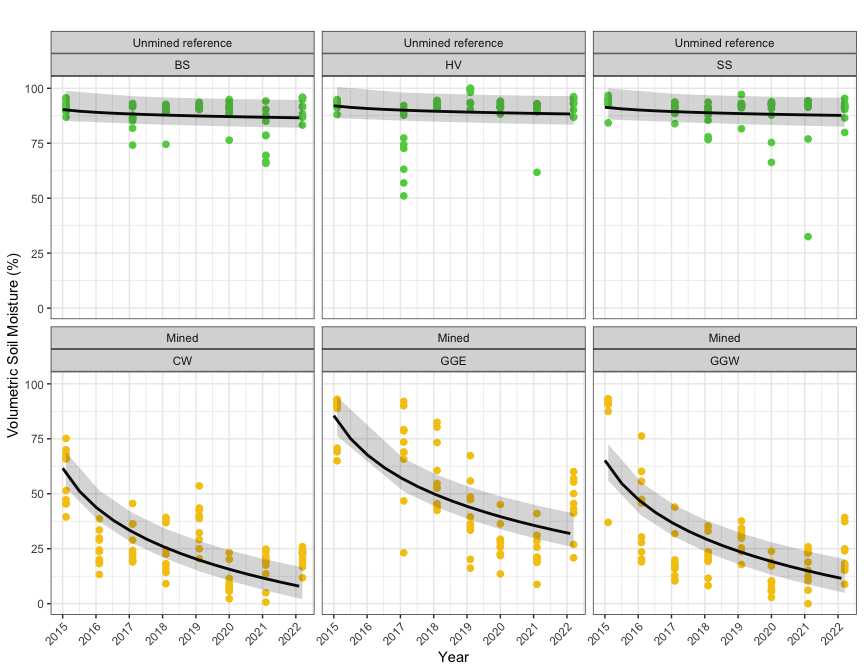

```r
nwdt <- expand.grid(Site=unique(newnsoil$Site),
                    Time=seq(2015,2022.1,length=15))
nwdt$Mine <- newnsoil$Mine[match(nwdt$Site,newnsoil$Site)]
nwdt$logYears <- log1p(nwdt$Time-2015)
nwdt$Rain <- quantile(newnsoil$Rain,.5)
nwdt["pred"] <- predict(mdl201,nwdt,level=1)


basic_plot + facet_wrap(vars(Mine,Site),ncol=3,nrow=2)  +
  geom_line(data=nwdt,
            aes(x=Time,y=pred), color='black',lwd=1)  +
  geom_ribbon(data=prd.env, aes(x=Time, ymin = boot_lwr, ymax = boot_upr),color=NA, lty=0, alpha = 0.2)
```

## Non-linear model

We could try to model decline in soil moisture as a log-logistic function (https://www.statforbiology.com/nonlinearregression/usefulequations#sygmoidal_curves). Function `SSfpl` implements the four parameter logistic or log-logistic function.

First step to fit a non-linear mixed effect model is to find the appropriate function to describe the trend. Here I tried a non-linear model fit for each Site using the `nlsList` function, but it does not converge for four sites.

```r
data <- newnsoil[,c("Site","Replicate","Mine","Rain","SoilMoisture")]
data$Time <- newnsoil$Time-2014
grData <- groupedData(SoilMoisture~Time+Rain|Site,data)

fm1 <- nlsList(SoilMoisture ~ SSfpl(Time, A, B, xmid, scal),
               start=c(A=90,B=c(30),xmid=1.3,scal=1.3),
               data = grData)
fm1
```

```
Call:
  Model: SoilMoisture ~ SSfpl(Time, A, B, xmid, scal) | Site
   Data: grData

Coefficients:
```

|  | A | B | xmid | scal |
| --- | --- | --- | --- | --- |
| CW | NA | NA | NA | NA |
| GGE | 83.27986 | 31.48677 | 3.992846 | 0.6591051 |
| GGW | NA | NA | NA | NA |
| BS | NA | NA | NA | NA |
| SS | 97.51526 | 88.14052 | 1.387928 | 1.3202351 |
| HV | NA | NA | NA | NA |

```
Degrees of freedom: 140 total; 132 residual
Residual standard error: 12.29819
```

Outcome of the model is very sensitive to starting values.

The model fitted to site GGE looks good:

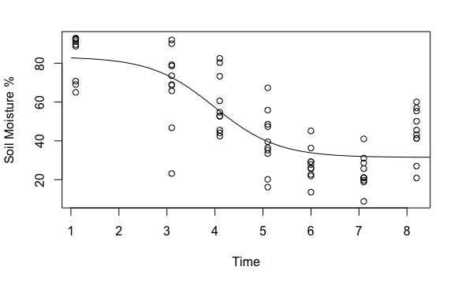

```r
x <- subset(grData,Site=="GGE")$Time
y <- subset(grData,Site=="GGE")$SoilMoisture
predx <- data.frame(Time=seq(1,9,length=50))
predy <- predict(fm1[["GGE"]],newdata=predx)
plot(x,y,xlab="Time",ylab="Soil Moisture %")
lines(predx$Time,predy)
```

The model fitted to site SS is Ok, but the response is very flat, so the selected fuction is not a good descriptor (not very informative) :

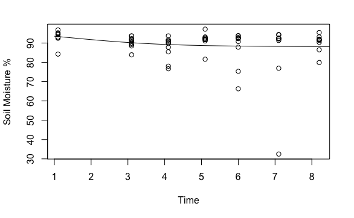

```r
x <- subset(grData,Site=="SS")$Time
y <- subset(grData,Site=="SS")$SoilMoisture
predx <- data.frame(Time=seq(1,9,length=50))
predy <- predict(fm1[["SS"]],newdata=predx)
plot(x,y,xlab="Time",ylab="Soil Moisture %")
lines(predx$Time,predy)
```

I have not been able to fit this function or alternative parametrizations (see `SSweibull`, `SSgompertz`, `SSlogis`) to the other sites, even when restricting the model to the three mined sites and changing the starting values. It looks to me like the response of soil moisture follow different trends in each site, and a single model can not quite capture this variation.

Without a good initial fit, it is not possible to fit a more complex model using the `nlme` function.